# What you need to know about crowdfunding on Kickstarter

Huy Le

March 21, 2019

```r
# Course: BUAN 5210
# Title: Kickstarter crowdfunding
# Purpose: Presentation
# Date: March 21, 2019
# Author: Huy Le
```

# Introduction

- *My data analysis:*
  - What is Kickstarter? How does it work?
  - Dataset from kaggle in 2017, 36542 observations and 18 variables.
  - Important variables:
    - Usd.pledged: total money that funded (usd).
    - Usd.goal: the minimum goal of a campaign (usd).
    - Duration: time running a campaign.
    - Ratio: usd.pledged/usd.goal.
    - State: successful or failed.
- *The expectation from this data analysis:*
  - For creators: Understanding how to increase your success rate beyond the project itself characteristics.
  - For backers: Recognizing which is worthy project to donate.
- *My findings:*
  - Failed projects tend to set up very high goal.
  - Longer duration, fewer support.
  - Launched date impact on the success.

# Finding 1: Unsuccessful projects tend setup its goal too high.

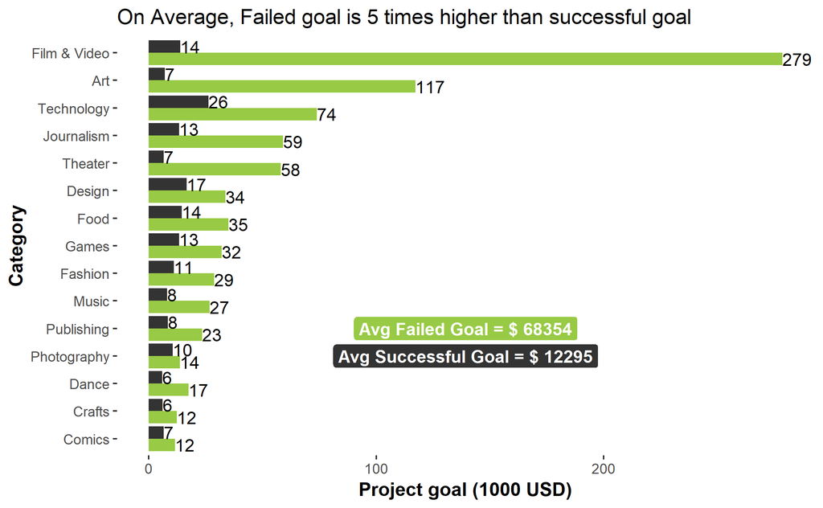

# Finding 2: Successful rate increase when duraion close to 30 days.

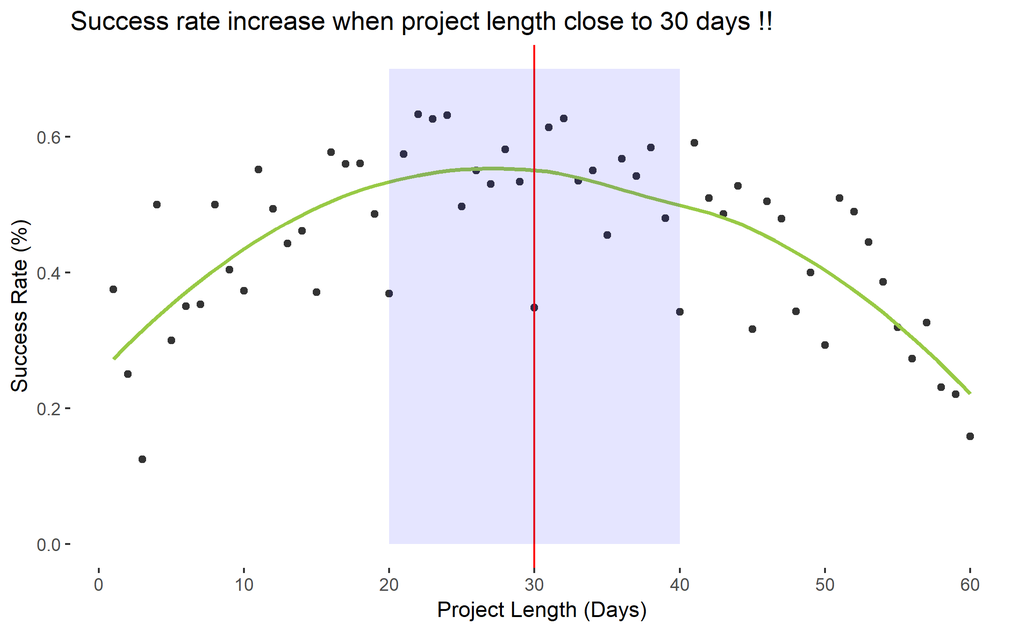

- Projects shoter 30days have higher success rate than those longer 30days
- Idealy, project should take length from 20-40 days

# Finding 3: December is not a good time to launch a campaign

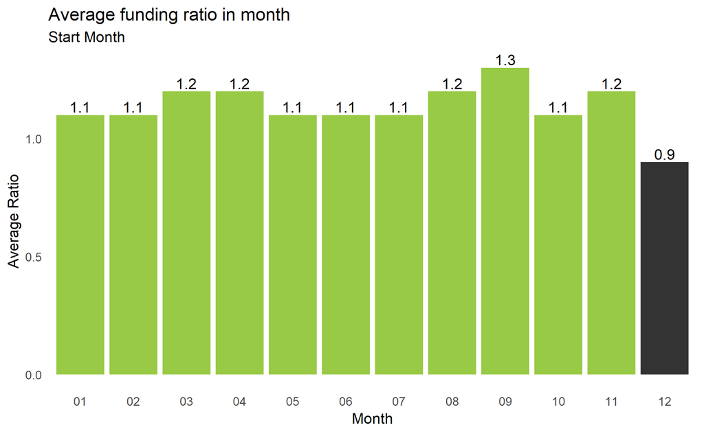

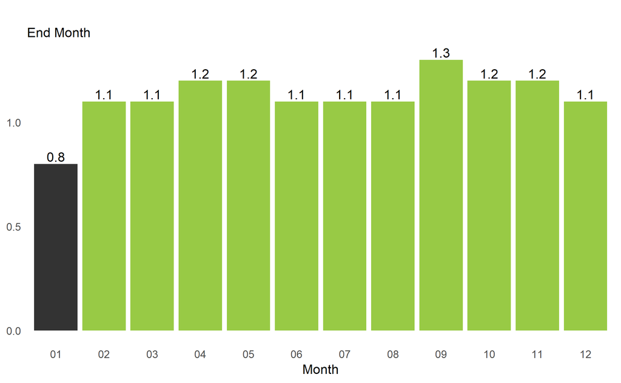

- Ratio = Funded amount/goal.
- Ratio < 1 that means project failed to reach their goal.
- On average, project launched in December or End in January have <1 ratio.

# Conclusion and Recommendations

- Minimum goal and duraion have a negative effect on successful rate.
- Setup a minium goal too high or a too long project can reduce the successful rate.
  - if Goal too high compare to the potential of project, it will make a project is less truthwothy
  - Shorter 30days project has higher success rate than longer 30days
- Time for start a campaign also importan. A campagin start in December or end in January face more difficulty to reach their goal.

**Recommendations**:

- *Considering divide your campaign into multi phrases with a lower minimum goal instead create one project with imposible mission.*
- *Maximum length of campain on kickstarter is 60 days, thus consider set a possible pair of goal-duration.*
- *20-40 days is ideal duration for campaign on Kickstarter.*
- *Avoid to launch you campaign in December and end in January*

# Contract information

Email: lehuy@seattleu.edu